# sw_engg

## Introduction

In today's rapidly evolving tech landscape, the software engineering job market stands as a dynamic and competitive field, offering diverse opportunities and challenges for professionals. As the demand for skilled software engineers continues to grow across industries, understanding the intricacies of job offerings, salary trends, and company dynamics becomes increasingly crucial for both job seekers and employers.

This comprehensive analysis of software engineering job market data aims to uncover valuable insights into the current state of the industry. By examining a rich dataset encompassing job titles, salaries, company ratings, and geographical information, we seek to paint a detailed picture of the opportunities and trends shaping the field. Our motivation stems from the desire to empower software engineers with data-driven insights for career decisions, assist companies in crafting competitive job offers, and contribute to a broader understanding of the tech job ecosystem.

Through rigorous data cleaning, exploratory data analysis, and visualization techniques, we will delve into various aspects of the software engineering job market. From salary distributions across different roles and locations to the relationship between company ratings and compensation, this analysis promises to reveal patterns and trends that can inform strategic decision-making for all stakeholders in the tech industry.

#### Importing packages

```python
import numpy as np
import pandas as pd
import matplotlib.pyplot as plt
import re
import seaborn as sns
```

#### Reading the .csv file

```python
data=pd.read_csv('Software Engineer Salaries.csv')
data.head()
```

|  | Company | Company Score | Job Title | Location | Date | Salary |
| --- | --- | --- | --- | --- | --- | --- |
| 0 | ViewSoft | 4.8 | Software Engineer | Manassas, VA | 8d | $68K - $94K (Glassdoor est.) |
| 1 | Workiva | 4.3 | Software Support Engineer | Remote | 2d | $61K - $104K (Employer est.) |
| 2 | Garmin International, Inc. | 3.9 | C# Software Engineer | Cary, NC | 2d | $95K - $118K (Glassdoor est.) |
| 3 | Snapchat | 3.5 | Software Engineer, Fullstack, 1+ Years of Expe... | Los Angeles, CA | 2d | $97K - $145K (Employer est.) |
| 4 | Vitesco Technologies Group AG | 3.1 | Software Engineer | Seguin, TX | 2d | $85K - $108K (Glassdoor est.) |

```python
# Display the last rows
data.tail()
```

|  | Company | Company Score | Job Title | Location | Date | Salary |
| --- | --- | --- | --- | --- | --- | --- |
| 865 | RXO | NaN | Software Engineer, Machine Learning Compute | San Francisco, CA | 6d | NaN |
| 866 | Infosys | NaN | Software Engineer - 3 (Apache NiFi) | Annapolis Junction, MD | 18d | NaN |
| 867 | Medtronic | NaN | Senior Software Engineer | Southfield, MI | 19d | NaN |
| 868 | NaN | NaN | Junior Python Developer | Charlotte, NC | 2d | NaN |
| 869 | NaN | NaN | GUI Software Engineer II - Surgical Robotics | Boston, MA | 10d | NaN |

```python
# Display basic information
data.info()
```

```
<class 'pandas.core.frame.DataFrame'>
RangeIndex: 870 entries, 0 to 869
Data columns (total 6 columns):
 #   Column         Non-Null Count  Dtype
---  ------         --------------  -----
 0   Company        868 non-null    object
 1   Company Score  789 non-null    float64
 2   Job Title      870 non-null    object
 3   Location       857 non-null    object
 4   Date           870 non-null    object
 5   Salary         764 non-null    object
dtypes: float64(1), object(5)
memory usage: 40.9+ KB
```

```python
# Check for null items in every column
data.isna().sum()
```

```
Company            2
Company Score     81
Job Title          0
Location          13
Date               0
Salary           106
dtype: int64
```

```python
#Extract the main job title for clearer categorization and analysis.
def clean_job_title(title):
    return re.split(r'\(|-|,', title)[0].strip()

data['Main Job Title'] = data['Job Title'].apply(clean_job_title)
```

```python
# Process salary data to extract meaningful values and categorize by salary type.
def extract_salary(salary_str):
    salary_range = re.findall(r'\$([\dK]+)', salary_str)
    salary_type = 'Employer est.' if 'Employer est.' in salary_str else 'Glassdoor est.'

    salary_range = [int(s.replace('K', '')) * 1000 for s in salary_range]
    if len(salary_range) == 2:
        return sum(salary_range) / 2, salary_type
    else:
        return None, salary_type
```

```python
# Add fields for average salary and distinguishes between employer and Glassdoor estimates, enabling further analytical flexibility
data['Salary'] = data['Salary'].astype(str)
data[['Average Salary', 'Estimate Type']] = data['Salary'].apply(
    lambda x: pd.Series(extract_salary(x))
)

data['Employer est'] = data['Estimate Type'] == 'Employer est.'
data['Glassdoor est'] =data['Estimate Type'] == 'Glassdoor est.'
```

```python
# Convert job posting dates into numerical representations for tracking posting recency.
def convert_date_to_days(date_str):
    if 'd' in date_str:
        return int(date_str.replace('d', '').replace('+', '').strip())
    elif 'h' in date_str:
        return int(date_str.replace('h', '').strip()) / 24
    elif 'w' in date_str:
        return int(date_str.replace('w', '').strip()) * 7
    else:
        return None

data['Days Since Posting'] = data['Date'].apply(convert_date_to_days)
```

```python
# Split location data into city, state, and remote fields to allow detailed geographic analysis.
def extract_location(location):
    parts = location.split(',')
    if len(parts) == 2:
        city = parts[0].strip()
        state = parts[1].strip()
        remote = False
    elif 'Remote' in location:
        city, state = None, None
        remote = True
    else:
        city, state = location, None
        remote = False
    return city, state, remote


data['Location'] = data['Location'].astype(str)
data[['City', 'State', 'Remote']] = data['Location'].apply(
    lambda x: pd.Series(extract_location(x))
)
```

```python
# Drop columns before changes
data_cleaned = data.drop(columns=['Job Title', 'Salary', 'Location'])

data_cleaned.head(10)
```

|  | Company | Company Score | Date | Main Job Title | Average Salary | Estimate Type | Employer est | Glassdoor est | Days Since Posting | City | State | Remote |
| --- | --- | --- | --- | --- | --- | --- | --- | --- | --- | --- | --- | --- |
| 0 | ViewSoft | 4.8 | 8d | Software Engineer | 81000.0 | Glassdoor est. | False | True | 8.0 | Manassas | VA | False |
| 1 | Workiva | 4.3 | 2d | Software Support Engineer | 82500.0 | Employer est. | True | False | 2.0 | None | None | True |
| 2 | Garmin International, Inc. | 3.9 | 2d | C# Software Engineer | 106500.0 | Glassdoor est. | False | True | 2.0 | Cary | NC | False |
| 3 | Snapchat | 3.5 | 2d | Software Engineer | 121000.0 | Employer est. | True | False | 2.0 | Los Angeles | CA | False |
| 4 | Vitesco Technologies Group AG | 3.1 | 2d | Software Engineer | 96500.0 | Glassdoor est. | False | True | 2.0 | Seguin | TX | False |
| 5 | Spotify | 3.9 | 1d | Backend Engineer II | 149000.0 | Employer est. | True | False | 1.0 | New York | NY | False |
| 6 | Infor | 4.0 | 7d | Associate Software Engineer | 85500.0 | Glassdoor est. | False | True | 7.0 | Alpharetta | GA | False |
| 7 | Amerisoft Corporation | 5.0 | 30d+ | Software Developers | 85500.0 | Glassdoor est. | False | True | 30.0 | Farmington Hills | MI | False |
| 8 | WHOOP | 3.3 | 10d | Software Engineer II | 121000.0 | Glassdoor est. | False | True | 10.0 | Boston | MA | False |
| 9 | PFF | 4.2 | 1d | Sr. Software Engineer | 168000.0 | Employer est. | True | False | 1.0 | None | None | True |

```python
# Impute missing values in key columns, ensuring consistency in analysis
data_cleaned['Average Salary'] = data_cleaned['Average Salary'].fillna(data_cleaned['Average Salary'].mean())
data_cleaned['Company Score'] = data_cleaned['Company Score'].fillna(data_cleaned['Company Score'].mean())
data_cleaned['City'] = data_cleaned['City'].fillna("UnKnown")
data_cleaned['State'] = data_cleaned['State'].fillna("UnKnown")
data_cleaned['Company'] = data_cleaned['Company'].fillna("UnKnown")
data_cleaned
```

|  | Company | Company Score | Date | Main Job Title | Average Salary | Estimate Type | Employer est | Glassdoor est | Days Since Posting | City | State | Remote |
| --- | --- | --- | --- | --- | --- | --- | --- | --- | --- | --- | --- | --- |
| 0 | ViewSoft | 4.800000 | 8d | Software Engineer | 81000.000000 | Glassdoor est. | False | True | 8.0 | Manassas | VA | False |
| 1 | Workiva | 4.300000 | 2d | Software Support Engineer | 82500.000000 | Employer est. | True | False | 2.0 | UnKnown | UnKnown | True |
| 2 | Garmin International, Inc. | 3.900000 | 2d | C# Software Engineer | 106500.000000 | Glassdoor est. | False | True | 2.0 | Cary | NC | False |
| 3 | Snapchat | 3.500000 | 2d | Software Engineer | 121000.000000 | Employer est. | True | False | 2.0 | Los Angeles | CA | False |
| 4 | Vitesco Technologies Group AG | 3.100000 | 2d | Software Engineer | 96500.000000 | Glassdoor est. | False | True | 2.0 | Seguin | TX | False |
| ... | ... | ... | ... | ... | ... | ... | ... | ... | ... | ... | ... | ... |
| 865 | RXO | 3.895311 | 6d | Software Engineer | 127957.937585 | Glassdoor est. | False | True | 6.0 | San Francisco | CA | False |
| 866 | Infosys | 3.895311 | 18d | Software Engineer | 127957.937585 | Glassdoor est. | False | True | 18.0 | Annapolis Junction | MD | False |
| 867 | Medtronic | 3.895311 | 19d | Senior Software Engineer | 127957.937585 | Glassdoor est. | False | True | 19.0 | Southfield | MI | False |
| 868 | UnKnown | 3.895311 | 2d | Junior Python Developer | 127957.937585 | Glassdoor est. | False | True | 2.0 | Charlotte | NC | False |
| 869 | UnKnown | 3.895311 | 10d | GUI Software Engineer II | 127957.937585 | Glassdoor est. | False | True | 10.0 | Boston | MA | False |

870 rows × 12 columns

```python
# Check if null values persist after cleaning
data_cleaned.isna().sum()
```

```
Company               0
Company Score         0
Date                  0
Main Job Title        0
Average Salary        0
Estimate Type         0
Employer est          0
Glassdoor est         0
Days Since Posting    0
City                  0
State                 0
Remote                0
dtype: int64
```

```python
# Top Companies by Average Salary
top_companies = data_cleaned.groupby('Company')['Average Salary'].mean().sort_values(ascending=False).head(20)
top_companies
```

```
Company
Intuitive Machines LLC                367500.000000
Teamups                               285000.000000
SNC                                   272500.000000
QinetiQ US                            272500.000000
Caterpillar                           260500.000000
Kaseware, Inc.                        255000.000000
DAIKIN COMFORT TECHNOLOGIES MFG LP    253000.000000
Allied Business Consulting            246000.000000
Athenahealth                          240000.000000
DraftKings                            233500.000000
University of Maryland                231500.000000
Yellow Duck Technologies Inc.         226000.000000
Federal Reserve Bank of Dallas        226000.000000
INTEL                                 223333.333333
Tickets.com                           220000.000000
Lockheed Martin                       220000.000000
Walter P Moore                        220000.000000
CPS Insurance Services                218500.000000
Enersys                               217500.000000
kasmo cloud solutions                 217500.000000
Name: Average Salary, dtype: float64
```

```python
# Group data for additional insights into company-specific salary trends.
data_cleaned.head(20).groupby(['Company'])['Average Salary'].mean()
```

```
Company
Amerisoft Corporation             85500.0
Amex                             112500.0
Athenahealth                     240000.0
Garmin International, Inc.       106500.0
HealthMine Services, Inc.         66500.0
Hertz                            179000.0
Honeywell                        113000.0
Infor                             85500.0
Legrand AV                       102500.0
Megaport                         108500.0
PFF                              168000.0
SOFT LABS NA                     106000.0
Salesforce                       101500.0
Snapchat                         105000.0
Spotify                          149000.0
ViewSoft                          81000.0
Vitesco Technologies Group AG     96500.0
WHOOP                            121000.0
Workiva                           82500.0
Name: Average Salary, dtype: float64
```

```python
# Groups data for additional insights into city-level averages.
data_cleaned.head(20).groupby(['City'])['Average Salary'].mean()
```

```
City
Aguadilla                 113000.000000
Alpharetta                 85500.000000
Boston                    180500.000000
Cary                      106500.000000
Farmington Hills           85500.000000
Los Angeles               105000.000000
Manassas                   81000.000000
Minneapolis-Saint Paul    102500.000000
New York                  149000.000000
Northborough              106000.000000
Plantation                112500.000000
San Francisco             101500.000000
Seattle                   179000.000000
Seguin                     96500.000000
UnKnown                   105666.666667
nan                       108500.000000
Name: Average Salary, dtype: float64
```

```python
top_companies = data_cleaned.groupby('City')['Average Salary'].mean().sort_values(ascending=False).head(20)
top_companies
```

```
City
Brookfield             387500.0
Newtown Square         285000.0
Burr Ridge             272500.0
Cupertino              240500.0
Johns Creek            233500.0
Chatsworth             228500.0
Foxborough             223000.0
Suwanee                217500.0
Carrollton             217500.0
Colony                 215000.0
Westlake Village       214000.0
Cincinnati             213000.0
McKinney               212500.0
Elkridge               211750.0
Fort George G Meade    210500.0
Greenwood Village      200000.0
Burlingame             195500.0
North Reading          193500.0
Secaucus               189000.0
Lexington              188500.0
Name: Average Salary, dtype: float64
```

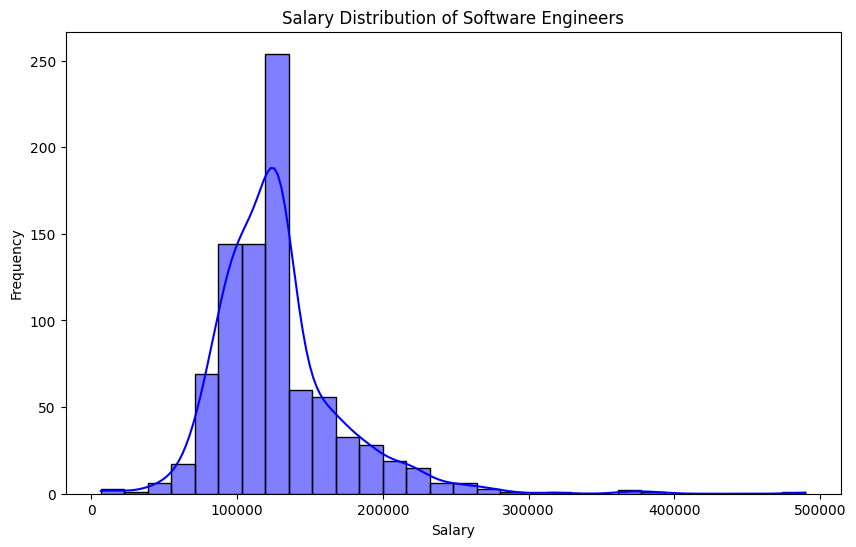

[figure not shown]

```
City
Brookfield             387500.0
Newtown Square         285000.0
Burr Ridge             272500.0
Cupertino              240500.0
Johns Creek            233500.0
Chatsworth             228500.0
Foxborough             223000.0
Suwanee                217500.0
Carrollton             217500.0
Colony                 215000.0
Westlake Village       214000.0
Cincinnati             213000.0
McKinney               212500.0
Elkridge               211750.0
Fort George G Meade    210500.0
Greenwood Village      200000.0
Burlingame             195500.0
North Reading          193500.0
Secaucus               189000.0
Lexington              188500.0
Name: Average Salary, dtype: float64
```

```python
plt.figure(figsize=(10, 6))
sns.histplot(data_cleaned['Average Salary'], kde=True, bins=30, color='blue')
plt.title('Salary Distribution of Software Engineers')
plt.xlabel('Salary')
plt.ylabel('Frequency')
plt.show()

plt.figure(figsize=(10, 6))
sns.scatterplot(x='Company Score', y='Average Salary', data=data_cleaned, hue='Main Job Title')
plt.title('Relationship Between Company Scores and Average Salary')
plt.xlabel('Company Score')
plt.ylabel('Average Salary')
plt.show()

# Top Cities by Average Salary
print(top_companies)
```

[figure not shown]

```python
# Plot first 50 average salaries by location
avg_salary_by_location = data_cleaned.head(50).groupby('City')['Average Salary'].mean().sort_values()
avg_salary_by_location.plot(kind='bar', figsize=(9, 6))
plt.title('Average Salary by Location')
plt.xlabel('Average Salary')
plt.ylabel('Location')
plt.show()
```

```python
# Group Average salaries by job titles
top_companies = data_cleaned.groupby('Main Job Title')['Average Salary'].mean().sort_values(ascending=False).head(20)
top_companies
```

```
Main Job Title
Apprentice ETL Software Engineer                 272500.0
Video Software Engineer                          272500.0
Solutions Engineer                               260500.0
Junior Java Software Engineer                    259000.0
Software Engineer / Simulation                   253000.0
Senior Software Engineer I                       250000.0
Embedded Flight Software Engineer – New Glenn    236500.0
Research Software Engineer                       229500.0
SOFTWARE ENGINEER 3                              228500.0
Software Engineer Senior â€“ Azure               227500.0
Software Performance Engineer                    226000.0
Software Development Test Engineer               223000.0
R&D Software Engineer II                         220000.0
Go Lang/Platform Engineer                        220000.0
SENIOR SOFTWARE ENGINEER                         217500.0
Machine Learning Software Engineer               216000.0
Freelance Web Developer                          215000.0
Software Engineer in Test                        212500.0
Elixir Software Engineer                         212500.0
CAD Software Engineer                            207000.0
Name: Average Salary, dtype: float64
```

```python
# Find top 20 companies by comapny score
top_companies = data_cleaned.groupby('Company')['Company Score'].mean().sort_values(ascending=False).head(20)
top_companies
```

```
Company
Tickets.com                                5.0
Annapurna Labs (U.S.) Inc.                 5.0
WSSC Water                                 5.0
Fusion Innovation                          5.0
OnMed                                      5.0
No.Inc                                     5.0
Gelber Group                               5.0
Cardlytics                                 5.0
Gundersen Health System                    5.0
Amerisoft Corporation                      5.0
Zurn Elkay Water Solutions                 5.0
Flysoft                                    5.0
Featurespace                               5.0
SOFT LABS NA                               5.0
Engineering Technology Associates, Inc.    5.0
West Bend Insurance Company                4.9
Link, LLC                                  4.9
ASUS Computer International                4.9
Fetch Package                              4.8
Audacy, Inc.                               4.8
Name: Company Score, dtype: float64
```

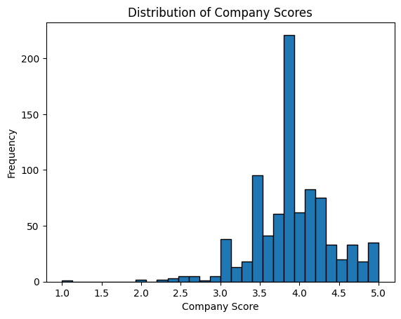

```python
# Plot distribution of company scores
data_cleaned['Company Score'].hist(bins=30,grid=False,edgecolor="black")
plt.title('Distribution of Company Scores')
plt.xlabel('Company Score')
plt.ylabel('Frequency')
plt.show()
```

```python
# Find minimum salary
data_cleaned['Average Salary'].min()
```

```
6500.0
```

```python
# Display the details
data_cleaned[data['Average Salary']==6500.0]
```

|  | Company | Company Score | Date | Main Job Title | Average Salary | Estimate Type | Employer est | Glassdoor est | Days Since Posting | City | State | Remote |
| --- | --- | --- | --- | --- | --- | --- | --- | --- | --- | --- | --- | --- |
| 69 | KAIROS Inc | 3.5 | 16d | Software Engineer | 6500.0 | Employer est. | True | False | 16.0 | Dahlgren | VA | False |

```python
# Find maximum salary
data_cleaned['Average Salary'].max()
```

```
490000.0
```

```python
# Display the details
data_cleaned[data['Average Salary']==490000.0]
```

|  | Company | Company Score | Date | Main Job Title | Average Salary | Estimate Type | Employer est | Glassdoor est | Days Since Posting | City | State | Remote |
| --- | --- | --- | --- | --- | --- | --- | --- | --- | --- | --- | --- | --- |
| 526 | BOEING | 4.0 | 30d+ | Senior Software Engineer | 490000.0 | Employer est. | True | False | 30.0 | Washington | DC | False |

```python
# Count unique salaries
data_cleaned['Average Salary'].value_counts()
```

```
Average Salary
127957.937585    133
95000.000000      12
135000.000000     11
99500.000000      11
106000.000000      9
                ...
141000.000000      1
159500.000000      1
182000.000000      1
152000.000000      1
259000.000000      1
Name: count, Length: 260, dtype: int64
```

```python
# Display info on 12 companies that give averagae salary of 95000
data_cleaned[data_cleaned['Average Salary']==95000.0]
```

|  | Company | Company Score | Date | Main Job Title | Average Salary | Estimate Type | Employer est | Glassdoor est | Days Since Posting | City | State | Remote |
| --- | --- | --- | --- | --- | --- | --- | --- | --- | --- | --- | --- | --- |
| 56 | Sonalysts, Inc. | 3.8 | 1d | Junior Software Engineer | 95000.0 | Employer est. | True | False | 1.0 | Waterford | CT | False |
| 58 | HealthStream | 3.6 | 10d | Software Developer | 95000.0 | Glassdoor est. | False | True | 10.0 | Nashville | TN | False |
| 88 | Synergy ECP | 4.4 | 2d | Junior Software Engineer | 95000.0 | Glassdoor est. | False | True | 2.0 | Fort Meade | MD | False |
| 94 | Vibrint | 3.5 | 11d | Software Engineer I | 95000.0 | Employer est. | True | False | 11.0 | United States | UnKnown | False |
| 178 | Origence | 4.0 | 1d | Software Engineer | 95000.0 | Glassdoor est. | False | True | 1.0 | UnKnown | UnKnown | True |
| 264 | Flysoft | 5.0 | 2d | Software Engineer | 95000.0 | Glassdoor est. | False | True | 2.0 | nan | UnKnown | False |
| 276 | Airgas | 4.1 | 12d | Software Engineer | 95000.0 | Glassdoor est. | False | True | 12.0 | Lehi | UT | False |
| 454 | Q9Software | 3.1 | 27d | IoT Engineer | 95000.0 | Employer est. | True | False | 27.0 | Milwaukee | WI | False |
| 471 | Fusion Innovation | 5.0 | 3d | Software Engineer | 95000.0 | Employer est. | True | False | 3.0 | Norcross | GA | False |
| 497 | Clarity Innovations, LLC | 3.4 | 13d | Software Engineer | 95000.0 | Employer est. | True | False | 13.0 | Denver | CO | False |
| 729 | Oracle | 4.0 | 11d | Ground Software Engineer | 95000.0 | Glassdoor est. | False | True | 11.0 | Virginia | UnKnown | False |
| 730 | Federal Reserve Bank of Boston | 4.1 | 14d | Experienced Front | 95000.0 | Glassdoor est. | False | True | 14.0 | Fort Collins | CO | False |

```python
# Observe some statistics
data_cleaned.describe()
```

|  | Company Score | Average Salary | Days Since Posting |
| --- | --- | --- | --- |
| count | 870.000000 | 870.000000 | 870.000000 |
| mean | 3.895311 | 127957.937585 | 13.432184 |
| std | 0.499888 | 43477.057639 | 11.148000 |
| min | 1.000000 | 6500.000000 | 1.000000 |
| 25% | 3.600000 | 101125.000000 | 3.000000 |
| 50% | 3.895311 | 126000.000000 | 10.000000 |
| 75% | 4.100000 | 138875.000000 | 26.750000 |
| max | 5.000000 | 490000.000000 | 30.000000 |

```python
# Get the average salary by city for a random sample of 20 rows
city_salary=data_cleaned.sample(20).groupby(['City'])['Average Salary'].mean()
```

```python
city_salary
```

```
City
Belcamp           127957.937585
Bethpage          112500.000000
Dallas             87000.000000
Dearborn           75500.000000
Eugene            167500.000000
Fairborn           99500.000000
Fairfax           119000.000000
Fort Meade         98500.000000
Lehi              115500.000000
Los Altos         126500.000000
Mason             115000.000000
Middleton         127957.937585
Mountain View     129500.000000
New York           80000.000000
Patuxent River    160000.000000
Phoenix            80000.000000
Seattle            99500.000000
Suwanee           217500.000000
United States     101500.000000
Vienna            127500.000000
Name: Average Salary, dtype: float64
```

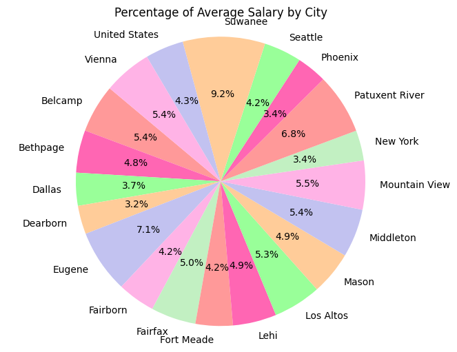

```python
# Pie chart
labels = city_salary.index
sizes = city_salary.values
custom_colors = ['#ff9999', '#ff66b3', '#99ff99', '#ffcc99', '#c2c2f0', '#ffb3e6', '#c2f0c2']

plt.figure(figsize=(8, 6))
plt.pie(sizes, labels=labels,colors=custom_colors, autopct='%1.1f%%', startangle=140)
plt.title('Percentage of Average Salary by City')
plt.axis('equal')
plt.show()
```

```python
# Randomly sample 20 rows and group by 'Main Job Title'
jobs_salary=data_cleaned.sample(20).groupby(['Main Job Title'])['Average Salary'].mean()
```

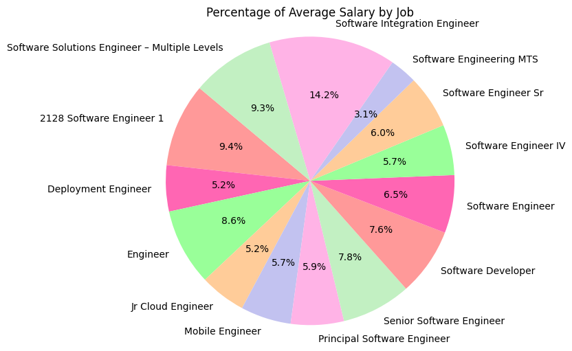

```python
labels = jobs_salary.index
sizes = jobs_salary.values
custom_colors = ['#ff9999', '#ff66b3', '#99ff99', '#ffcc99', '#c2c2f0', '#ffb3e6', '#c2f0c2']

plt.figure(figsize=(8, 6))
plt.pie(sizes, labels=labels,colors=custom_colors, autopct='%1.1f%%', startangle=140)
plt.title('Percentage of Average Salary by Job')
plt.axis('equal')
plt.show()
```

```python
# Randomly sample 20 rows and group by Company
company_salary=data_cleaned.sample(20).groupby(['Company'])['Company Score'].mean()
```

[figure not shown]

```python
labels = company_salary.index
sizes = company_salary.values
custom_colors = ['#ff9999', '#ff66b3', '#99ff99', '#ffcc99', '#c2c2f0', '#ffb3e6', '#c2f0c2']

plt.figure(figsize=(8, 6))
plt.pie(sizes, labels=labels,colors=custom_colors, autopct='%1.1f%%', startangle=140)
plt.title('Percentage of Average Salary by Job')
plt.axis('equal')
plt.show()
```

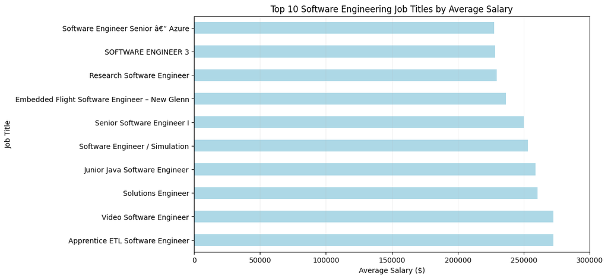

```python
top_10_job_titles = data_cleaned.groupby('Main Job Title')['Average Salary'].mean().sort_values(ascending=False).head(10)

plt.figure(figsize=(10, 6))
top_10_job_titles.plot(kind='barh', color='lightblue')
plt.title('Top 10 Software Engineering Job Titles by Average Salary')
plt.xlabel('Average Salary ($)')
plt.ylabel('Job Title')
plt.grid(axis='x', alpha=0.2)
plt.xlim(0, 300000)
plt.show()
```

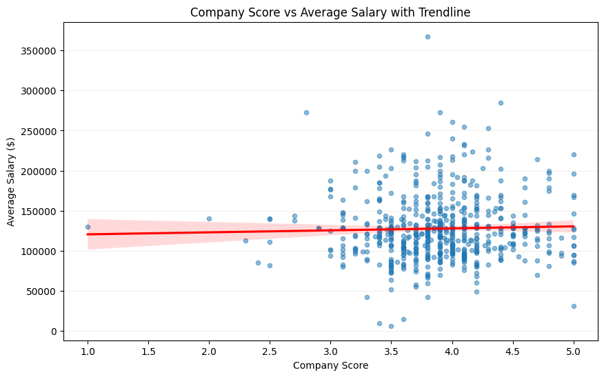

```python
# plot a scatter plot with a regression line to show the relationship between the "Company Score" and "Average Salary"
company_salary_score = data_cleaned.groupby('Company').agg({
    'Average Salary': 'mean',
    'Company Score': 'mean'
}).dropna()

plt.figure(figsize=(10, 6))
sns.regplot(
    data=company_salary_score,
    x='Company Score',
    y='Average Salary',
    scatter_kws={'s':20, 'alpha':0.5},
    line_kws={'color':'red'}
)
plt.title('Company Score vs Average Salary with Trendline')
plt.xlabel('Company Score')
plt.ylabel('Average Salary ($)')
plt.grid(axis='y', alpha=0.2)
plt.show()
```

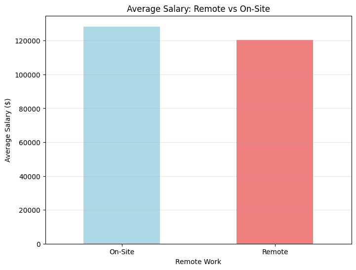

```python
# comparing the average salary between remote and on-site work
remote_vs_onsite = data_cleaned.groupby('Remote')['Average Salary'].mean()

plt.figure(figsize=(8, 6))
remote_vs_onsite.plot(kind='bar', color=['lightblue', 'lightcoral'])
plt.title('Average Salary: Remote vs On-Site')
plt.xlabel('Remote Work')
plt.ylabel('Average Salary ($)')
plt.xticks(ticks=[0, 1], labels=['On-Site', 'Remote'], rotation=0)
plt.grid(axis='y', alpha=0.3)
plt.show()
```

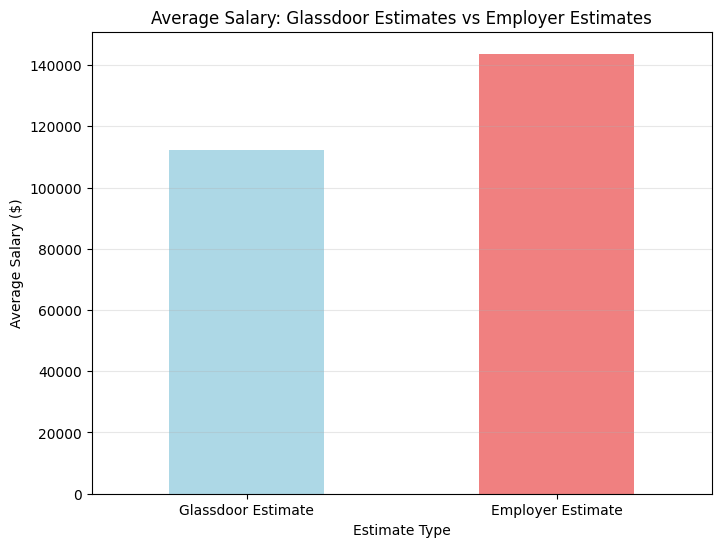

```python
#  comparing the average salary between "Glassdoor Estimates" and "Employer Estimates"
estimate_type_salary = data_cleaned.groupby('Employer est')['Average Salary'].mean()
estimate_type_salary.index = ['Glassdoor Estimate', 'Employer Estimate']

plt.figure(figsize=(8, 6))
estimate_type_salary.plot(kind='bar', color=['lightblue', 'lightcoral'])
plt.title('Average Salary: Glassdoor Estimates vs Employer Estimates')
plt.xlabel('Estimate Type')
plt.ylabel('Average Salary ($)')
plt.grid(axis='y', alpha=0.3)
plt.xticks(rotation=0)
plt.show()
```

```python
# Calculating a combined score for companies based on both their "Average Salary" and "Company Score."
company_stats = data_cleaned.groupby('Company').agg({
    'Average Salary': 'mean',
    'Company Score': 'mean'
}).dropna()

company_stats['Salary Norm'] = company_stats['Average Salary'] / company_stats['Average Salary'].max()
company_stats['Score Norm'] = company_stats['Company Score'] / company_stats['Company Score'].max()
company_stats['Combined Score'] = (company_stats['Salary Norm'] + company_stats['Score Norm']) / 2

top_companies_by_combined_score = company_stats.sort_values(by='Combined Score', ascending=False).head(10)

top_companies_by_combined_score[['Average Salary', 'Company Score', 'Combined Score']]
```

| Company | Average Salary | Company Score | Combined Score |
| --- | --- | --- | --- |
| Intuitive Machines LLC | 367500.0 | 3.8 | 0.880000 |
| Teamups | 285000.0 | 4.4 | 0.827755 |
| Tickets.com | 220000.0 | 5.0 | 0.799320 |
| DAIKIN COMFORT TECHNOLOGIES MFG LP | 253000.0 | 4.3 | 0.774218 |
| WSSC Water | 196500.0 | 5.0 | 0.767347 |
| Elder Research | 214000.0 | 4.7 | 0.761156 |
| QinetiQ US | 272500.0 | 3.9 | 0.760748 |
| Kaseware, Inc. | 255000.0 | 4.1 | 0.756939 |
| Caterpillar | 260500.0 | 4.0 | 0.754422 |
| Favorited | 200000.0 | 4.8 | 0.752109 |

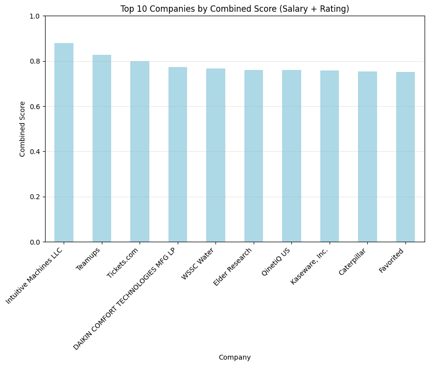

```python
# visualizing the top 10 companies by their combined score
plt.figure(figsize=(10, 6))
top_companies_by_combined_score['Combined Score'].plot(kind='bar', color='lightblue')
plt.title('Top 10 Companies by Combined Score (Salary + Rating)')
plt.xlabel('Company')
plt.ylabel('Combined Score')
plt.xticks(rotation=45, ha='right')
plt.ylim(0, 1)
plt.grid(axis='y', alpha=0.3)
plt.show()
```

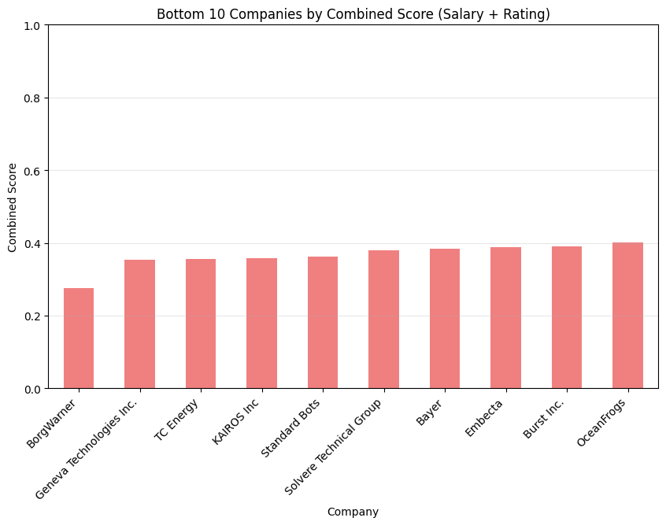

```python
# visualizing the bottom 10 companies by their combined score
bottom_companies_by_combined_score = company_stats.sort_values(by='Combined Score', ascending=True).head(10)

plt.figure(figsize=(10, 6))
bottom_companies_by_combined_score['Combined Score'].plot(kind='bar', color='lightcoral')
plt.title('Bottom 10 Companies by Combined Score (Salary + Rating)')
plt.xlabel('Company')
plt.ylabel('Combined Score')
plt.xticks(rotation=45, ha='right')
plt.ylim(0, 1)
plt.grid(axis='y', alpha=0.3)
plt.show()
```

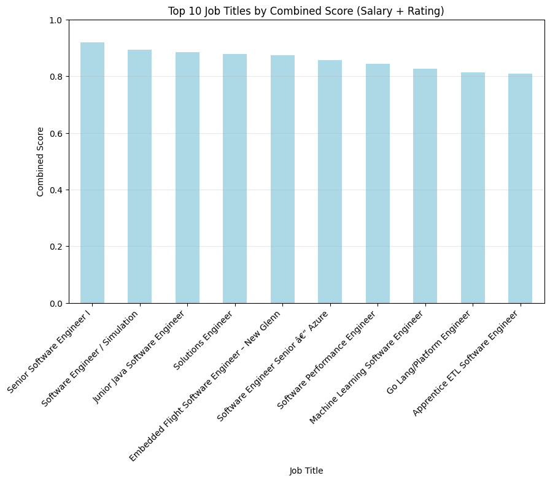

```python
# calculating the top 10 job titles by combined score (salary and rating)
job_title_stats = data_cleaned.groupby('Main Job Title').agg({
    'Average Salary': 'mean',
    'Company Score': 'mean'
}).dropna()

job_title_stats['Salary Norm'] = job_title_stats['Average Salary'] / job_title_stats['Average Salary'].max()
job_title_stats['Score Norm'] = job_title_stats['Company Score'] / job_title_stats['Company Score'].max()
job_title_stats['Combined Score'] = (job_title_stats['Salary Norm'] + job_title_stats['Score Norm']) / 2

top_job_titles_by_combined_score = job_title_stats.sort_values(by='Combined Score', ascending=False).head(10)
bottom_job_titles_by_combined_score = job_title_stats.sort_values(by='Combined Score', ascending=True).head(10)

plt.figure(figsize=(10, 6))
top_job_titles_by_combined_score['Combined Score'].plot(kind='bar', color='lightblue')
plt.title('Top 10 Job Titles by Combined Score (Salary + Rating)')
plt.xlabel('Job Title')
plt.ylabel('Combined Score')
plt.xticks(rotation=45, ha='right')
plt.ylim(0, 1)
plt.grid(axis='y', alpha=0.3)
plt.show()
```

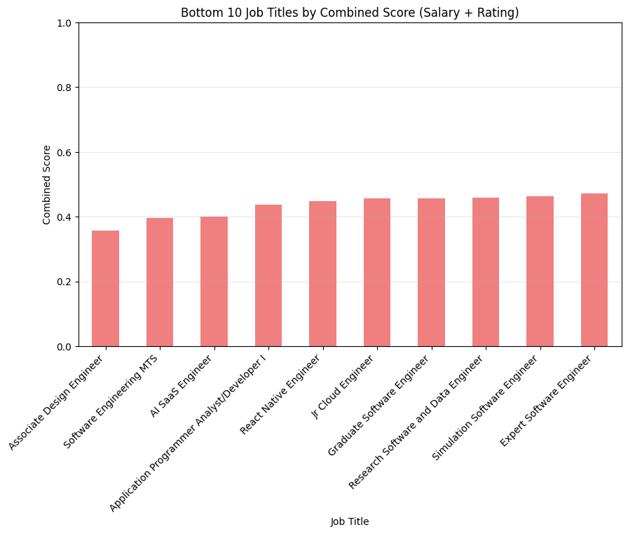

```python
# # visualizing the bottom 10 Job titles by their combined score
plt.figure(figsize=(10, 6))
bottom_job_titles_by_combined_score['Combined Score'].plot(kind='bar', color='lightcoral')
plt.title('Bottom 10 Job Titles by Combined Score (Salary + Rating)')
plt.xlabel('Job Title')
plt.ylabel('Combined Score')
plt.xticks(rotation=45, ha='right')
plt.ylim(0, 1)
plt.grid(axis='y', alpha=0.3)
plt.show()
```

#### Hypothesis Testing: Remote vs. On-site Salaries

```python
from scipy import stats
```

```python
# perform a t-test to compare the average salaries between remote and onsite workers
remote_salaries = data_cleaned[data_cleaned['Remote']]['Average Salary']
onsite_salaries = data_cleaned[~data_cleaned['Remote']]['Average Salary']

t_statistic, p_value = stats.ttest_ind(remote_salaries, onsite_salaries)

print(f"T-statistic: {t_statistic}")
print(f"P-value: {p_value}")
```

```
T-statistic: -1.1273742642999833
P-value: 0.25989581909071174
```

#### Correlation Analysis

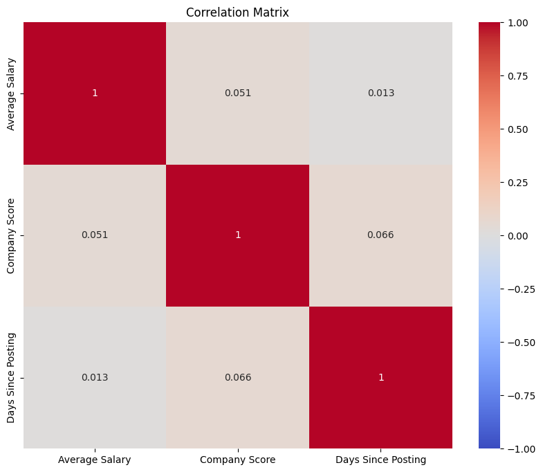

```python
# generating a heatmap of the correlation matrix between Average Salary, Company Score, and Days Since Posting
correlation_matrix = data_cleaned[['Average Salary', 'Company Score', 'Days Since Posting']].corr()

plt.figure(figsize=(10, 8))
sns.heatmap(correlation_matrix, annot=True, cmap='coolwarm', vmin=-1, vmax=1, center=0)
plt.title('Correlation Matrix')
plt.show()
```

#### ANOVA: Salaries Across Different Groups

```python
# performing two separate ANOVA (Analysis of Variance) tests to compare the differences in average salary across different cities and job titles
city_groups = [group for _, group in data_cleaned.groupby('City')['Average Salary']]
f_statistic_cities, p_value_cities = stats.f_oneway(*city_groups)

print("ANOVA Results for Cities:")
print(f"F-statistic: {f_statistic_cities}")
print(f"P-value: {p_value_cities}")

# ANOVA for job titles
job_title_groups = [group for _, group in data_cleaned.groupby('Main Job Title')['Average Salary']]
f_statistic_jobs, p_value_jobs = stats.f_oneway(*job_title_groups)

print("\nANOVA Results for Job Titles:")
print(f"F-statistic: {f_statistic_jobs}")
print(f"P-value: {p_value_jobs}")
```

```
ANOVA Results for Cities:
F-statistic: 1.0069030572913458
P-value: 0.46900482923691245

ANOVA Results for Job Titles:
F-statistic: 1.0412676839609836
P-value: 0.33933199662830205
```

#### Salary Prediction Model - Random Forest Regressor

```python
from sklearn.model_selection import train_test_split
from sklearn.ensemble import RandomForestRegressor
from sklearn.preprocessing import LabelEncoder
from sklearn.metrics import mean_squared_error, r2_score
```

```python
# Prepare the features
features = ['Main Job Title', 'City', 'State', 'Company Score', 'Remote']
X = data_cleaned[features]
y = data_cleaned['Average Salary']

# Encode categorical variables
le = LabelEncoder()
for feature in ['Main Job Title', 'City', 'State']:
    X.loc[:, feature] = le.fit_transform(X[feature])  # Avoid SettingWithCopyWarning

# Split the data
X_train, X_test, y_train, y_test = train_test_split(X, y, test_size=0.2, random_state=42)

# Train the model
rf_model = RandomForestRegressor(n_estimators=100, random_state=42)
rf_model.fit(X_train, y_train)

# Make predictions
y_pred = rf_model.predict(X_test)

# Evaluate the model
mse = mean_squared_error(y_test, y_pred)
r2 = r2_score(y_test, y_pred)

print(f'Mean Squared Error: {mse}')
print(f'R-squared: {r2}')
```

```
Mean Squared Error: 2537080572.288081
R-squared: -0.15463795273130176
```

#### K-means clustering

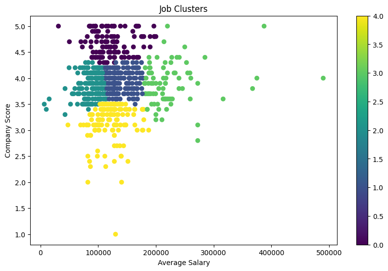

```python
from sklearn.cluster import KMeans
from sklearn.preprocessing import StandardScaler

# Prepare the features for clustering
cluster_features = ['Average Salary', 'Company Score']
X_cluster = data_cleaned[cluster_features]

# Standardize the features
scaler = StandardScaler()
X_cluster_scaled = scaler.fit_transform(X_cluster)

# Perform K-means clustering
kmeans = KMeans(n_clusters=5, random_state=42)
data_cleaned['Cluster'] = kmeans.fit_predict(X_cluster_scaled)

# Visualize the clusters
plt.figure(figsize=(10, 6))
scatter = plt.scatter(X_cluster['Average Salary'], X_cluster['Company Score'], c=data_cleaned['Cluster'], cmap='viridis')
plt.colorbar(scatter)
plt.xlabel('Average Salary')
plt.ylabel('Company Score')
plt.title('Job Clusters')
plt.show()
```

#### Job Recommendation System

For a content-based job recommendation system, we'll use TF-IDF and cosine similarity:

```python
from sklearn.feature_extraction.text import TfidfVectorizer
from sklearn.metrics.pairwise import cosine_similarity

# Combine job title and company for content
data_cleaned['content'] = data_cleaned['Main Job Title'] + ' ' + data_cleaned['Company']

# Create TF-IDF matrix
tfidf = TfidfVectorizer(stop_words='english')
tfidf_matrix = tfidf.fit_transform(data_cleaned['content'])

# Compute cosine similarity
cosine_sim = cosine_similarity(tfidf_matrix, tfidf_matrix)

# Function to get job recommendations
def get_recommendations(job_index, cosine_sim=cosine_sim):
    sim_scores = list(enumerate(cosine_sim[job_index]))
    sim_scores = sorted(sim_scores, key=lambda x: x[1], reverse=True)
    sim_scores = sim_scores[1:11]  # Top 10 similar jobs
    job_indices = [i[0] for i in sim_scores]
    return data_cleaned.iloc[job_indices]

# Example: Get recommendations for the first job
recommended_jobs = get_recommendations(0)
print(recommended_jobs[['Main Job Title', 'Company', 'Average Salary']])
```

```
               Main Job Title               Company  Average Salary
20          Software Engineer        7-Eleven, Inc.   117500.000000
138         Software Engineer                No.Inc   106500.000000
477  Senior Software Engineer                 Front   172000.000000
115         Software Engineer  Two Six Technologies   127957.937585
188         Software Engineer  Two Six Technologies   104000.000000
193         Software Engineer  Two Six Technologies   132500.000000
202         Software Engineer           W R Systems   114500.000000
129         Software Engineer  Independent Software   126500.000000
459         Software Engineer  Captivation Software   106500.000000
643         Software Engineer  Captivation Software   144000.000000
```

#### Analyzing Trends in Job Postings and Salaries

```python
data_cleaned['Date'] = pd.Timestamp.now() - pd.to_timedelta(data_cleaned['Days Since Posting'], unit='D')
```

```python
data_cleaned.set_index('Date', inplace=True)
```

```
RMSE: 10266.82903520027
```

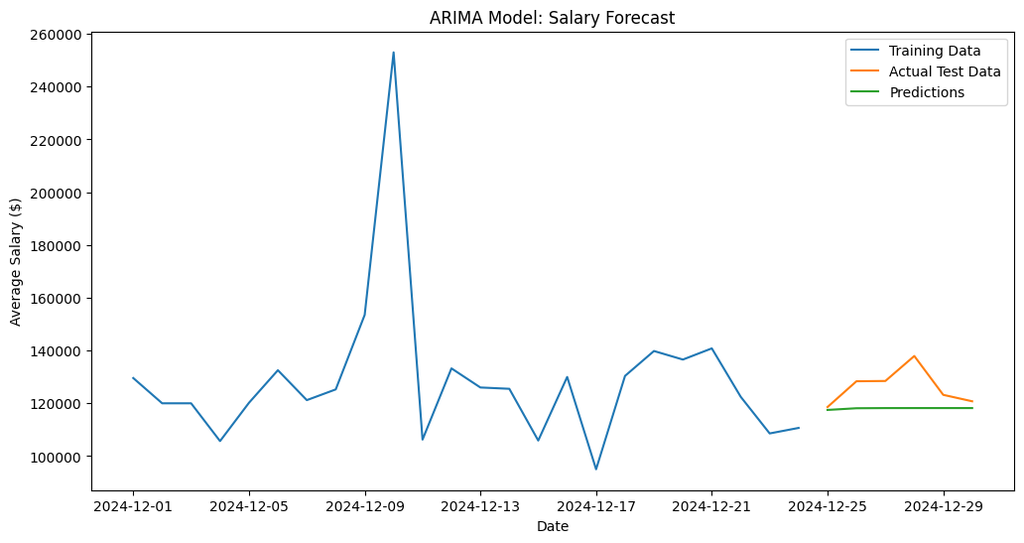

```python
# Prepare the data
salary_series = data_cleaned['Average Salary'].resample('D').mean().fillna(method='ffill')

# Split the data into train and test sets
train_size = int(len(salary_series) * 0.8)
train, test = salary_series[:train_size], salary_series[train_size:]

# Fit ARIMA model
from statsmodels.tsa.arima.model import ARIMA
model = ARIMA(train, order=(1,1,1))
model_fit = model.fit()

# Make predictions
predictions = model_fit.forecast(steps=len(test))

# Calculate RMSE
from sklearn.metrics import mean_squared_error
import numpy as np
rmse = np.sqrt(mean_squared_error(test, predictions))
print(f'RMSE: {rmse}')

# Plot the results
plt.figure(figsize=(12, 6))
plt.plot(train.index, train, label='Training Data')
plt.plot(test.index, test, label='Actual Test Data')
plt.plot(test.index, predictions, label='Predictions')
plt.title('ARIMA Model: Salary Forecast')
plt.xlabel('Date')
plt.ylabel('Average Salary ($)')
plt.legend()
plt.show()
```

#### Text Mining for Key Skills and Technologies

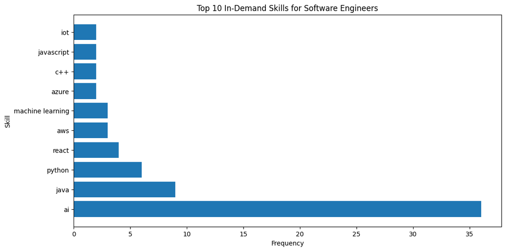

```python
import re
from collections import Counter

# Function to extract skills from text
def extract_skills(text):
    # List of common programming languages and technologies
    skills = ['python', 'java', 'javascript', 'c++', 'ruby', 'php', 'html', 'css',
              'sql', 'nosql', 'react', 'angular', 'vue', 'node.js', 'django',
              'flask', 'spring', 'aws', 'azure', 'gcp', 'docker', 'kubernetes',
              'machine learning', 'ai', 'data science', 'blockchain', 'iot']

    found_skills = [skill for skill in skills if skill in text.lower()]
    return found_skills

# Extract skills from job titles and descriptions
data_cleaned['Skills'] = data_cleaned['Main Job Title'] + ' ' + data_cleaned['Company']
data_cleaned['Skills'] = data_cleaned['Skills'].apply(extract_skills)

# Count skill frequencies
all_skills = [skill for skills in data_cleaned['Skills'] for skill in skills]
skill_freq = Counter(all_skills)

# Visualize top 10 skills
plt.figure(figsize=(12, 6))
skill_freq.most_common(10)[::-1]
plt.barh(*zip(*skill_freq.most_common(10)))
plt.title('Top 10 In-Demand Skills for Software Engineers')
plt.xlabel('Frequency')
plt.ylabel('Skill')
plt.show()
```

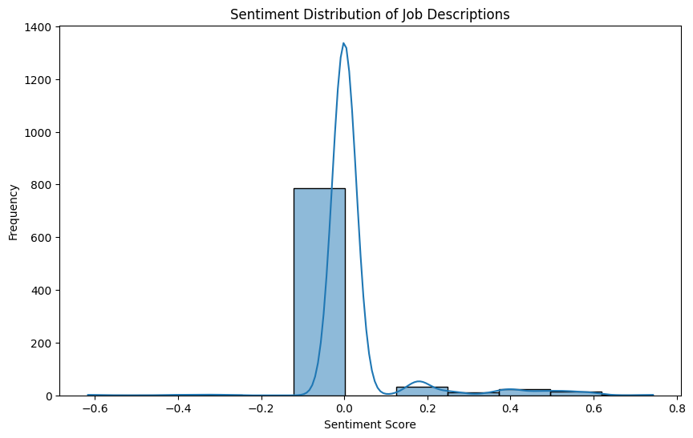

```
Correlation between job description sentiment and salary: 0.01

Top 5 Companies with Most Positive Job Descriptions:
Company
Innovative Solutions and Support         0.7430
Super Micro Computer                     0.5994
Technical Intelligence Solutions, LLC    0.5859
Inspire Brands                           0.5719
Space Coast Intelligent Solutions        0.5719
Name: Sentiment, dtype: float64

Top 5 Companies with Most Negative Job Descriptions:
Company
SICK, Inc.                      -0.6166
Discord                         -0.4019
Early Warning Services          -0.3400
Electronic Warfare Associates   -0.2960
Oliver Wyman Group               0.0000
Name: Sentiment, dtype: float64
```

```python
import nltk
from nltk.sentiment import SentimentIntensityAnalyzer

nltk.download('vader_lexicon')

sia = SentimentIntensityAnalyzer()

# Function to perform sentiment analysis
def analyze_sentiment(text):
    return sia.polarity_scores(text)['compound']

# Perform sentiment analysis on job descriptions
data_cleaned['Sentiment'] = data_cleaned['Company'].apply(analyze_sentiment)

# Visualize sentiment distribution
plt.figure(figsize=(10, 6))
sns.histplot(data_cleaned['Sentiment'], kde=True)
plt.title('Sentiment Distribution of Job Descriptions')
plt.xlabel('Sentiment Score')
plt.ylabel('Frequency')
plt.show()

# Analyze correlation between sentiment and salary
correlation = data_cleaned['Sentiment'].corr(data_cleaned['Average Salary'])
print(f"Correlation between job description sentiment and salary: {correlation:.2f}")

# Top 5 companies with most positive job descriptions
top_positive = data_cleaned.groupby('Company')['Sentiment'].mean().sort_values(ascending=False).head()
print("\nTop 5 Companies with Most Positive Job Descriptions:")
print(top_positive)

# Top 5 companies with most negative job descriptions
top_negative = data_cleaned.groupby('Company')['Sentiment'].mean().sort_values().head()
print("\nTop 5 Companies with Most Negative Job Descriptions:")
print(top_negative)
```

```python
print(data_cleaned.columns)
```

```
Index(['Company', 'Company Score', 'Main Job Title', 'Average Salary',
       'Estimate Type', 'Employer est', 'Glassdoor est', 'Days Since Posting',
       'City', 'State', 'Remote', 'Cluster', 'content', 'Skills', 'Sentiment'],
      dtype='object')
```

#### Interactive Dashboard

```python
from geopy.geocoders import Nominatim
from geopy.exc import GeocoderTimedOut, GeocoderServiceError
import time
```

```python
geolocator = Nominatim(user_agent="my_app")

# Function to geocode with error handling and rate limiting
def geocode_location(city, state):
    try:
        location = geolocator.geocode(f"{city}, {state}", exactly_one=True)
        time.sleep(1)  # Rate limiting to avoid overwhelming the service
        if location:
            return location.latitude, location.longitude
        else:
            return None, None
    except (GeocoderTimedOut, GeocoderServiceError):
        time.sleep(2)  # Wait a bit longer if there's an error
        return None, None

# Apply geocoding to your DataFrame
data_cleaned['Latitude'], data_cleaned['Longitude'] = zip(*data_cleaned.apply(lambda row: geocode_location(row['City'], row['State']), axis=1))
```

```python
data_cleaned.columns
```

[output not shown]

```python
# Initialize the Dash app
app = dash.Dash(__name__)

# Define the layout
app.layout = html.Div([
    html.H1("Software Engineering Job Market Dashboard"),

    dcc.Dropdown(
        id='job-title-dropdown',
        options=[{'label': i, 'value': i} for i in data_cleaned['Main Job Title'].unique()],
        value='Software Engineer',
        multi=False
    ),

    dcc.Graph(id='salary-location-map'),

    dcc.Graph(id='salary-distribution')
])

# Define callbacks
@app.callback(
    [Output('salary-location-map', 'figure'),
     Output('salary-distribution', 'figure')],
    [Input('job-title-dropdown', 'value')]
)
def update_graphs(selected_job_title):
    filtered_df = data_cleaned[data_cleaned['Main Job Title'] == selected_job_title]

    # Create geospatial visualization
    fig_map = px.scatter_mapbox(filtered_df,
                                lat='Latitude',
                                lon='Longitude',
                                color='Average Salary',
                                size='Average Salary',
                                hover_name='Company',
                                zoom=3,
                                mapbox_style="open-street-map")

    # Create salary distribution
    fig_dist = px.histogram(filtered_df, x='Average Salary', nbins=30)

    return fig_map, fig_dist

# Run the app
if __name__ == '__main__':
    app.run_server(debug=True)
```

[output not shown]

[output cut: 38 more lines]

[output not shown]

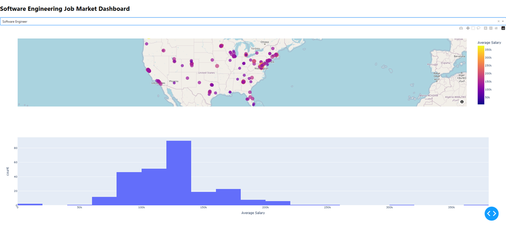

#### Feature Engineering

Create a tech stack score:

```python
import re

# Define a list of common technologies
tech_stack = ['python', 'java', 'javascript', 'c++', 'sql', 'aws', 'azure', 'docker', 'kubernetes', 'react', 'angular', 'vue', 'node.js', 'mongodb', 'tensorflow', 'pytorch']

def calculate_tech_score(job_title):
    score = sum(1 for tech in tech_stack if tech.lower() in job_title.lower())
    return score

data_cleaned['Tech Stack Score'] = data_cleaned['Main Job Title'].apply(calculate_tech_score)
```

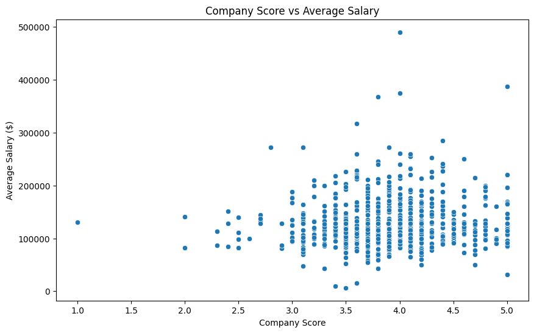

```
Correlation between Company Score and Average Salary: 0.05
```

```python
plt.figure(figsize=(10, 6))
sns.scatterplot(data=data_cleaned, x='Company Score', y='Average Salary')
plt.title('Company Score vs Average Salary')
plt.xlabel('Company Score')
plt.ylabel('Average Salary ($)')
plt.show()

correlation = data_cleaned['Company Score'].corr(data_cleaned['Average Salary'])
print(f"Correlation between Company Score and Average Salary: {correlation:.2f}")
```

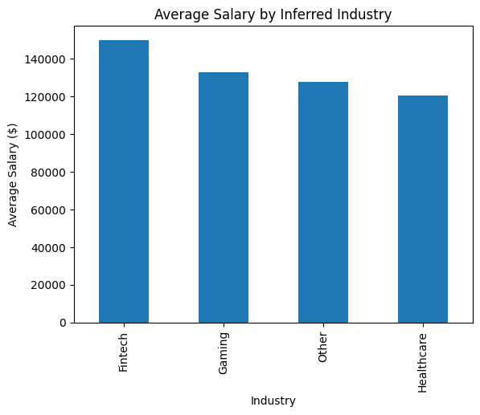

```python
def infer_industry(text):
    if any(keyword in text.lower() for keyword in ['health', 'medical', 'pharma']):
        return 'Healthcare'
    elif any(keyword in text.lower() for keyword in ['bank', 'finance', 'invest']):
        return 'Fintech'
    elif any(keyword in text.lower() for keyword in ['game', 'gaming']):
        return 'Gaming'
    else:
        return 'Other'

data_cleaned['Inferred Industry'] = data_cleaned['Company'].apply(infer_industry)

industry_salary = data_cleaned.groupby('Inferred Industry')['Average Salary'].mean().sort_values(ascending=False)
industry_salary.plot(kind='bar')
plt.title('Average Salary by Inferred Industry')
plt.xlabel('Industry')
plt.ylabel('Average Salary ($)')
plt.show()
```

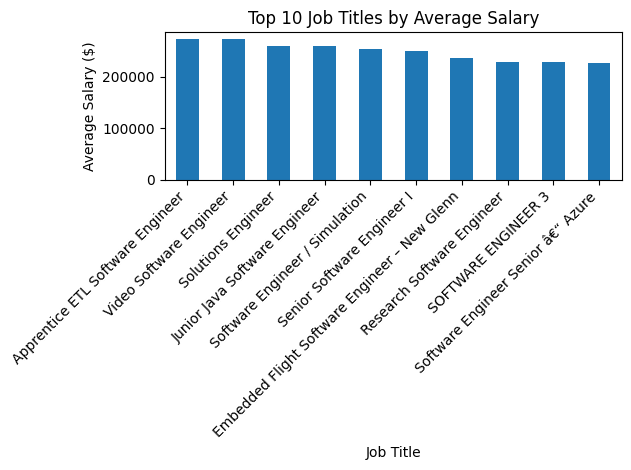

```python
job_title_salary = data_cleaned.groupby('Main Job Title')['Average Salary'].mean().sort_values(ascending=False).head(10)
job_title_salary.plot(kind='bar')
plt.title('Top 10 Job Titles by Average Salary')
plt.xlabel('Job Title')
plt.ylabel('Average Salary ($)')
plt.xticks(rotation=45, ha='right')
plt.tight_layout()
plt.show()
```

The title "Apprentice ETL Software Engineer" shows the highest average salary among the listed job roles.

The roles listed, such as "Embedded Flight Software Engineer" and "Solutions Engineer", suggest that positions requiring niche expertise (e.g., simulation, flight software, cloud computing) tend to offer higher salaries.

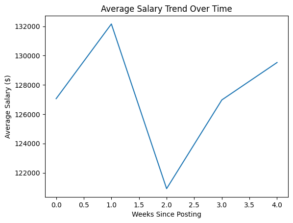

```python
data_cleaned['Weeks Since Posting'] = data_cleaned['Days Since Posting'] // 7
weekly_salary_trend = data_cleaned.groupby('Weeks Since Posting')['Average Salary'].mean()
weekly_salary_trend.plot(kind='line')
plt.title('Average Salary Trend Over Time')
plt.xlabel('Weeks Since Posting')
plt.ylabel('Average Salary ($)')
plt.show()
```

The graph shows the trend of average salaries over time in relation to the number of weeks since the job posting.